# workflow_codealong

Jeanne McClure

2022-07-13

## 1. Introduction

Let’s get familiar with the R Markdown layout and syntax.

### 1.1 YAML Heading

Yaml is a data serialization language. It contains, title, author, dates, type of document etc. YAML is picky!

Check out this site on[Yamll heading](https://zsmith27.github.io/rmarkdown_crash-course/lesson-4-yaml-headers.html) by @Smith.

### 1.2 R Markdown

### 1.2a. Markdown Syntax

R Markdowns syntax is based off of [Pandoc’s Markdown](https://pandoc.org/MANUAL.html).

##### Headers

```
+ # Level One(largest)
+ ## Level Two
+ ### Level Three
+ #### Level Four
+ ##### Level Five(smallest)
```

##### Bullet points

Bullet points can be used with a `single dash` or a `plus sign`

> Outcomes:
- Learn R Markdown.
  - Learn about Yaml heading.
  - Learn R Markdown Syntax.
- Learn how to read in data.
- Learn to wrangle data.

### 1.3. Add a Code Chunk

1. Menu Bar > ‘Code’ > ‘insert chunk’
2. Add a code chunk by holding down `Ctrl` + `Alt` + `I`

## 2. WorkFlow Recap

### 3.1 Workflow

Each organization may have a familiar workflow. In Learning Analytics we use a five step process:

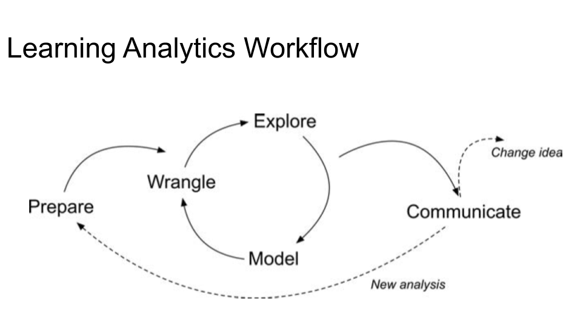

## 0. Introduction

Provide a brief overview or case study.

- Include your R1: *research questions!*

## 1. Prepare

Load Packages

```r
#Load necessary packages
library(tidyverse)
library(here)
```

## 2. Wrangle

### a. *Import Data*

#### Data Source #1: Log Data

Log-trace data is data generated from our interactions with digital technologies, such as archived data from social media postings. In education, an increasingly common source of log-trace data is that generated from interactions with LMS and other digital tools.

The data we will use has already been “wrangled” quite a bit and is a summary type of log-trace data: the number of minutes students spent on the course. While this data type is fairly straightforward, there are even more complex sources of log-trace data out there (e.g., time stamps associated with when students started and stopped accessing the course).

Let’s use the `read_csv()` function from {readr} to import our `log-data.csv` file directly from our data folder and name this data set `time_spent`, to help us to quickly recollect what function it serves in this analysis:

```r
#load with read_csv package
time_spent <- read_csv("~/Kim/LASER Institute 2022/laser-orientation/foundational-skills/foundation_lab_2/data/log-data.csv")
```

Now let’s load it with the {here} package.

```r
#load with here package
time_spent <- read_csv(here("data", "log-data.csv"))
#inspect data
time_spent
```

```
## # A tibble: 716 × 6
##    student_id course_id     gender enrollment_reason enrollment_stat… time_spent
##         <dbl> <chr>         <chr>  <chr>             <chr>                 <dbl>
##  1      60186 AnPhA-S116-01 M      Course Unavailab… Approved/Enroll…      2087.
##  2      66693 AnPhA-S116-01 M      Course Unavailab… Approved/Enroll…      2309.
##  3      66811 AnPhA-S116-01 F      Course Unavailab… Approved/Enroll…      5299.
##  4      66862 AnPhA-S116-01 F      Course Unavailab… Approved/Enroll…      1747.
##  5      67508 AnPhA-S116-01 F      Scheduling Confl… Approved/Enroll…      2668.
##  6      70532 AnPhA-S116-01 F      Learning Prefere… Approved/Enroll…      2938.
##  7      77010 AnPhA-S116-01 F      Learning Prefere… Approved/Enroll…      1533.
##  8      85249 AnPhA-S116-01 F      Course Unavailab… Approved/Enroll…      1210.
##  9      85411 AnPhA-S116-01 F      Scheduling Confl… Approved/Enroll…       473.
## 10      85583 AnPhA-S116-01 F      Scheduling Confl… Approved/Enroll…      5532.
## # … with 706 more rows
```

#### Data Source #2: Academic Achievement Data

We’ll load the data in the same way as earlier but take a quick peek but including the name of our data frame in the code chunk as well:

```r
#load data 2: Academic Achievement
gradebook <- read_csv(here("data", "gradebook-summary.csv"))
#inspect data with glimpse
glimpse(gradebook)
```

```
## Rows: 717
## Columns: 4
## $ student_id            <dbl> 43146, 44638, 47448, 47979, 48797, 51943, 52326,…
## $ course_id             <chr> "FrScA-S216-02", "OcnA-S116-01", "FrScA-S216-01"…
## $ total_points_possible <dbl> 1217, 1676, 1232, 1833, 2225, 1222, 1775, 2225, …
## $ total_points_earned   <dbl> 1150.00, 1384.23, 1116.00, 1492.73, 1994.75, 70.…
```

#### Data Source #3: Self-Report Survey

The third data source is a self-report survey. This was data collected before the start of the course. The survey included ten items, each corresponding to one of three motivation measures: interest, utility value, and perceived competence. These were chosen for their alignment with one way to think about students’ motivation, to what extent they expect to do well (corresponding to their perceived competence) and their value for what they are learning (corresponding to their interest and utility value).

```r
#load data 3:Self-Report Survey
survey <- read_csv(here("data", "survey.csv"))
#inspect data with view - yes the "V" is capitalized
View(survey)
```

### b. Tidy data

##### Data 1: TIME SPENT

# separate course_id variable in the time-spent

```r
time_spent %>%
  separate(course_id,
           c("subject", "semester", "section"))
```

```
## # A tibble: 716 × 8
##    student_id subject semester section gender enrollment_reason enrollment_stat…
##         <dbl> <chr>   <chr>    <chr>   <chr>  <chr>             <chr>
##  1      60186 AnPhA   S116     01      M      Course Unavailab… Approved/Enroll…
##  2      66693 AnPhA   S116     01      M      Course Unavailab… Approved/Enroll…
##  3      66811 AnPhA   S116     01      F      Course Unavailab… Approved/Enroll…
##  4      66862 AnPhA   S116     01      F      Course Unavailab… Approved/Enroll…
##  5      67508 AnPhA   S116     01      F      Scheduling Confl… Approved/Enroll…
##  6      70532 AnPhA   S116     01      F      Learning Prefere… Approved/Enroll…
##  7      77010 AnPhA   S116     01      F      Learning Prefere… Approved/Enroll…
##  8      85249 AnPhA   S116     01      F      Course Unavailab… Approved/Enroll…
##  9      85411 AnPhA   S116     01      F      Scheduling Confl… Approved/Enroll…
## 10      85583 AnPhA   S116     01      F      Scheduling Confl… Approved/Enroll…
## # … with 706 more rows, and 1 more variable: time_spent <dbl>
```

```r
time_spent_2 <- time_spent %>%
  separate(course_id,
           c("subject", "semester", "section"))

time_spent_2
```

```
## # A tibble: 716 × 8
##    student_id subject semester section gender enrollment_reason enrollment_stat…
##         <dbl> <chr>   <chr>    <chr>   <chr>  <chr>             <chr>
##  1      60186 AnPhA   S116     01      M      Course Unavailab… Approved/Enroll…
##  2      66693 AnPhA   S116     01      M      Course Unavailab… Approved/Enroll…
##  3      66811 AnPhA   S116     01      F      Course Unavailab… Approved/Enroll…
##  4      66862 AnPhA   S116     01      F      Course Unavailab… Approved/Enroll…
##  5      67508 AnPhA   S116     01      F      Scheduling Confl… Approved/Enroll…
##  6      70532 AnPhA   S116     01      F      Learning Prefere… Approved/Enroll…
##  7      77010 AnPhA   S116     01      F      Learning Prefere… Approved/Enroll…
##  8      85249 AnPhA   S116     01      F      Course Unavailab… Approved/Enroll…
##  9      85411 AnPhA   S116     01      F      Scheduling Confl… Approved/Enroll…
## 10      85583 AnPhA   S116     01      F      Scheduling Confl… Approved/Enroll…
## # … with 706 more rows, and 1 more variable: time_spent <dbl>
```

```r
# mutate minutes to hours on time spent and save as new variable.
time_spent_2 <- time_spent_2 %>%
  mutate(time_spent_hours = time_spent / 60)
time_spent_2
```

```
## # A tibble: 716 × 9
##    student_id subject semester section gender enrollment_reason enrollment_stat…
##         <dbl> <chr>   <chr>    <chr>   <chr>  <chr>             <chr>
##  1      60186 AnPhA   S116     01      M      Course Unavailab… Approved/Enroll…
##  2      66693 AnPhA   S116     01      M      Course Unavailab… Approved/Enroll…
##  3      66811 AnPhA   S116     01      F      Course Unavailab… Approved/Enroll…
##  4      66862 AnPhA   S116     01      F      Course Unavailab… Approved/Enroll…
##  5      67508 AnPhA   S116     01      F      Scheduling Confl… Approved/Enroll…
##  6      70532 AnPhA   S116     01      F      Learning Prefere… Approved/Enroll…
##  7      77010 AnPhA   S116     01      F      Learning Prefere… Approved/Enroll…
##  8      85249 AnPhA   S116     01      F      Course Unavailab… Approved/Enroll…
##  9      85411 AnPhA   S116     01      F      Scheduling Confl… Approved/Enroll…
## 10      85583 AnPhA   S116     01      F      Scheduling Confl… Approved/Enroll…
## # … with 706 more rows, and 2 more variables: time_spent <dbl>,
## #   time_spent_hours <dbl>
```

##### Data 2: GRADEBOOK

```r
# separate the course_id variable
gradebook <- gradebook %>%
  separate(course_id, c("subject", "semester", "section"))

gradebook
```

```
## # A tibble: 717 × 6
##    student_id subject semester section total_points_possible total_points_earned
##         <dbl> <chr>   <chr>    <chr>                   <dbl>               <dbl>
##  1      43146 FrScA   S216     02                       1217               1150
##  2      44638 OcnA    S116     01                       1676               1384.
##  3      47448 FrScA   S216     01                       1232               1116
##  4      47979 OcnA    S216     01                       1833               1493.
##  5      48797 PhysA   S116     01                       2225               1995.
##  6      51943 FrScA   S216     03                       1222                 70
##  7      52326 AnPhA   S216     01                       1775               1519.
##  8      52446 PhysA   S116     01                       2225               2198
##  9      53447 FrScA   S116     01                       1212               1173
## 10      53475 FrScA   S116     02                       1212                  0
## # … with 707 more rows
```

```r
# Mutate to a proportion, take total points earned divide by total points. Save as new variable proportion_earned.
gradebook <- gradebook %>%
  mutate(proportion_earned = (total_points_earned / total_points_possible))

#inspect data
gradebook
```

```
## # A tibble: 717 × 7
##    student_id subject semester section total_points_possible total_points_earned
##         <dbl> <chr>   <chr>    <chr>                   <dbl>               <dbl>
##  1      43146 FrScA   S216     02                       1217               1150
##  2      44638 OcnA    S116     01                       1676               1384.
##  3      47448 FrScA   S216     01                       1232               1116
##  4      47979 OcnA    S216     01                       1833               1493.
##  5      48797 PhysA   S116     01                       2225               1995.
##  6      51943 FrScA   S216     03                       1222                 70
##  7      52326 AnPhA   S216     01                       1775               1519.
##  8      52446 PhysA   S116     01                       2225               2198
##  9      53447 FrScA   S116     01                       1212               1173
## 10      53475 FrScA   S116     02                       1212                  0
## # … with 707 more rows, and 1 more variable: proportion_earned <dbl>
```

##### Data 3: SURVEY

```r
#inspect data
survey
```

```
## # A tibble: 662 × 26
##    student_ID course_ID subject semester section   int   val percomp    tv    q1
##    <chr>      <chr>     <chr>   <chr>    <chr>   <dbl> <dbl>   <dbl> <dbl> <dbl>
##  1 43146      FrScA-S2… FrScA   S216     02        4.2  3.67     4    3.86     4
##  2 44638      OcnA-S11… OcnA    S116     01        4    3        3    3.57     4
##  3 47448      FrScA-S2… FrScA   S216     01        4.2  3        3    3.71     5
##  4 47979      OcnA-S21… OcnA    S216     01        4    3.67     2.5  3.86     4
##  5 48797      PhysA-S1… PhysA   S116     01        3.8  3.67     3.5  3.71     4
##  6 51943      FrScA-S2… FrScA   S216     03        3.8  3.67     3.5  3.71     4
##  7 52326      AnPhA-S2… AnPhA   S216     01        3.6  4        3    4        4
##  8 52446      PhysA-S1… PhysA   S116     01        4.2  3.67     3    4        4
##  9 53447      FrScA-S1… FrScA   S116     01        3.8  2        3    3        5
## 10 53475      FrScA-S2… FrScA   S216     01        4.8  3.33     4    4.14     5
## # … with 652 more rows, and 16 more variables: q2 <dbl>, q3 <dbl>, q4 <dbl>,
## #   q5 <dbl>, q6 <dbl>, q7 <dbl>, q8 <dbl>, q9 <dbl>, q10 <dbl>, date.x <dttm>,
## #   post_int <dbl>, post_uv <dbl>, post_tv <dbl>, post_percomp <dbl>,
## #   date.y <dttm>, date <dttm>
```

```r
# load janitor to clean variable names that do not match
library(janitor)
#clean column
survey <- clean_names(survey)

#inspect data to check for consistency with other data
survey
```

```
## # A tibble: 662 × 26
##    student_id course_id subject semester section   int   val percomp    tv    q1
##    <chr>      <chr>     <chr>   <chr>    <chr>   <dbl> <dbl>   <dbl> <dbl> <dbl>
##  1 43146      FrScA-S2… FrScA   S216     02        4.2  3.67     4    3.86     4
##  2 44638      OcnA-S11… OcnA    S116     01        4    3        3    3.57     4
##  3 47448      FrScA-S2… FrScA   S216     01        4.2  3        3    3.71     5
##  4 47979      OcnA-S21… OcnA    S216     01        4    3.67     2.5  3.86     4
##  5 48797      PhysA-S1… PhysA   S116     01        3.8  3.67     3.5  3.71     4
##  6 51943      FrScA-S2… FrScA   S216     03        3.8  3.67     3.5  3.71     4
##  7 52326      AnPhA-S2… AnPhA   S216     01        3.6  4        3    4        4
##  8 52446      PhysA-S1… PhysA   S116     01        4.2  3.67     3    4        4
##  9 53447      FrScA-S1… FrScA   S116     01        3.8  2        3    3        5
## 10 53475      FrScA-S2… FrScA   S216     01        4.8  3.33     4    4.14     5
## # … with 652 more rows, and 16 more variables: q2 <dbl>, q3 <dbl>, q4 <dbl>,
## #   q5 <dbl>, q6 <dbl>, q7 <dbl>, q8 <dbl>, q9 <dbl>, q10 <dbl>, date_x <dttm>,
## #   post_int <dbl>, post_uv <dbl>, post_tv <dbl>, post_percomp <dbl>,
## #   date_y <dttm>, date <dttm>
```